# Analysis of Happiness Across the World

## Spring 2025 Data Science Project

#### Kimber Gonzalez Lopez, Christina Jung, Olade Kounou, Matthew Mueller, Franco Romero

##### Contributions

A: Project idea  
B: Dataset Curation and Preprocessing  
C: Data Exploration and Summary Statistics  
D: ML Algorithm Design/Development  
E: ML Algorithm Training and Test Data Analysis  
F: Visualization, Result Analysis, Conclusion  
G: Final Tutorial Report Creation  
H: Additional (not listed above)

- Kimber Gonzalez Lopez: He worked on the ML algorithm design/development, training, and test data analysis.
- Christina Jung: She came up with the project idea, worked on the introduction, imported the initial CSV files, and deployed the project.
- Olade Kounou: He wrote the second and third hypotheses, and worked on the insights and conclusions.
- Matthew Mueller: He wrote the fourth hypothesis, and worked on the visualizations.
- Franco Romero: He worked on the data curation/preprocessing, the first hypothesis, and formatting/proofreading.
- Introduction
- Data Curation
  - Source and Explanation
  - Imports
  - Parsing and Organizing
- Exploratory Data Analysis
  - First Hypothesis
  - Second Hypothesis
  - Third Hypothesis
  - Fourth Hypothesis
- Primary Analysis
  - Feature Engineering
  - Training and Testing Linear Regression Model
  - Training and Testing Random Forest Model
    - Feature Importances
- Visualization
  - Model Comparison
  - Feature Importances
- Insights and Conclusions

## Introduction

In the context of signficant political and economic changes, the global state of well-being has become increasingly important. In our report, we wanted to analyze the factors that may or may not contribute to a country's happiness. In order to do this, we have decided to use the [World Happiness Report](https://www.kaggle.com/datasets/unsdsn/world-happiness), which analyzes data from 2015 to 2019 from over 170 countries. This dataset provides many features and describes the extent to which it can impact a country's happiness. This includes GDP per Capita, Family, Life Expectancy, Freedom, Generosity, Trust Government Corruption.

With this dataset, our primary explorations which of these features would have the strongest correlation with happiness. In conjunction, we also explore whether or not happiness would vary by year or by region. Additionally, we compare the predictive performance between linear regression and random forest models in estimating happiness scores.

Through these explorations we hope to provide insight for governments and policy makers on ways to objectively increase the quality of life, well-being, and happiness on their respective countries.

## Data Curation

### Source and Explanation

As previously mentioned, we used the [World Happiness Report](https://www.kaggle.com/datasets/unsdsn/world-happiness) dataset. This dataset is based on Gallup World Poll data from 2015 to 2019 from 170 countries, ranking each country by happiness score using the Cantril ladder. The Cantril ladder asks the respondent to rate their current life out of 10 where the best possible life is a 10 and the worst possible life is a 0. The values of each of the six factors (GDP per capita, social support, healthy life expectancy, freedom, perceptions of corruption, and generosity) are estimates of the extent that the given factor contributes to the happiness score. By the end of the parsing and organizing, the columns we are left with are:

- Country
- Region
- Happiness Score
- GDP per Capita
- Social Support
- Healthy Life Expectancy
- Freedom
- Perceptions of Corruption
- Generosity
- Year

### Imports

```python
import pandas as pd
import numpy as np
import matplotlib.pyplot as plt
import seaborn as sns
from scipy.stats import pearsonr, ttest_ind, f_oneway
from sklearn.model_selection import train_test_split
from sklearn.preprocessing import StandardScaler
from sklearn.linear_model import LinearRegression
from sklearn.ensemble import RandomForestRegressor
from sklearn.metrics import mean_absolute_error, mean_squared_error, r2_score
```

### Parsing and Organizing

First, we load in each DataFrame and check their shapes and columns.

Learn more about DataFrames: https://www.w3schools.com/python/pandas/pandas_dataframes.asp

```python
df_2015 = pd.read_csv('2015.csv')
df_2016 = pd.read_csv('2016.csv')
df_2017 = pd.read_csv('2017.csv')
df_2018 = pd.read_csv('2018.csv')
df_2019 = pd.read_csv('2019.csv')

df_years = [(df_2015, 2015), (df_2016, 2016), (df_2017, 2017), (df_2018, 2018), (df_2019, 2019)]

# Check the shape and columns of each DataFrame
for df, year in df_years:
    print(f"DataFrame for {year}:")
    print(df.shape)
    print(df.columns)
```

```
DataFrame for 2015:
(158, 12)
Index(['Country', 'Region', 'Happiness Rank', 'Happiness Score',
       'Standard Error', 'Economy (GDP per Capita)', 'Family',
       'Health (Life Expectancy)', 'Freedom', 'Trust (Government Corruption)',
       'Generosity', 'Dystopia Residual'],
      dtype='object')
DataFrame for 2016:
(157, 13)
Index(['Country', 'Region', 'Happiness Rank', 'Happiness Score',
       'Lower Confidence Interval', 'Upper Confidence Interval',
       'Economy (GDP per Capita)', 'Family', 'Health (Life Expectancy)',
       'Freedom', 'Trust (Government Corruption)', 'Generosity',
       'Dystopia Residual'],
      dtype='object')
DataFrame for 2017:
(155, 12)
Index(['Country', 'Happiness.Rank', 'Happiness.Score', 'Whisker.high',
       'Whisker.low', 'Economy..GDP.per.Capita.', 'Family',
       'Health..Life.Expectancy.', 'Freedom', 'Generosity',
       'Trust..Government.Corruption.', 'Dystopia.Residual'],
      dtype='object')
DataFrame for 2018:
(156, 9)
Index(['Overall rank', 'Country or region', 'Score', 'GDP per capita',
       'Social support', 'Healthy life expectancy',
       'Freedom to make life choices', 'Generosity',
       'Perceptions of corruption'],
      dtype='object')
DataFrame for 2019:
(156, 9)
Index(['Overall rank', 'Country or region', 'Score', 'GDP per capita',
       'Social support', 'Healthy life expectancy',
       'Freedom to make life choices', 'Generosity',
       'Perceptions of corruption'],
      dtype='object')
```

We see that the columns are not consistent across each DataFrame, so we need to standardize the columns across the years.

```python
new_columns = ['Country', 'Region', 'Happiness_Score', 'GDP_per_Capita',
               'Social_Support', 'Healthy_Life_Expectancy', 'Freedom',
               'Perceptions_of_Corruption', 'Generosity', 'Year']

new_columns_missing_region = ['Country', 'Happiness_Score', 'GDP_per_Capita',
                        'Social_Support', 'Healthy_Life_Expectancy', 'Freedom',
                        'Perceptions_of_Corruption', 'Generosity', 'Year', 'Region']

# 2015
df_2015_clean = df_2015[['Country', 'Region', 'Happiness Score',
                        'Economy (GDP per Capita)', 'Family',
                        'Health (Life Expectancy)', 'Freedom',
                        'Trust (Government Corruption)', 'Generosity']].copy()
df_2015_clean['Year'] = 2015
df_2015_clean.columns = new_columns

# 2016
df_2016_clean = df_2016[['Country', 'Region', 'Happiness Score',
                        'Economy (GDP per Capita)', 'Family',
                        'Health (Life Expectancy)', 'Freedom',
                        'Trust (Government Corruption)', 'Generosity']].copy()
df_2016_clean['Year'] = 2016
df_2016_clean.columns = new_columns

# 2017
df_2017_clean = df_2017[['Country', 'Happiness.Score',
                        'Economy..GDP.per.Capita.', 'Family',
                        'Health..Life.Expectancy.', 'Freedom',
                        'Trust..Government.Corruption.', 'Generosity']].copy()
df_2017_clean['Year'] = 2017
df_2017_clean['Region'] = pd.NA  # Missing in 2017 dataset
df_2017_clean.columns = new_columns_missing_region

# 2018
df_2018_clean = df_2018[['Country or region', 'Score',
                        'GDP per capita', 'Social support',
                        'Healthy life expectancy', 'Freedom to make life choices',
                        'Generosity', 'Perceptions of corruption']].copy()
df_2018_clean['Year'] = 2018
df_2018_clean['Region'] = pd.NA  # Missing in 2018 dataset
df_2018_clean.columns = new_columns_missing_region

# 2019
df_2019_clean = df_2019[['Country or region', 'Score',
                        'GDP per capita', 'Social support',
                        'Healthy life expectancy', 'Freedom to make life choices',
                        'Generosity', 'Perceptions of corruption']].copy()
df_2019_clean['Year'] = 2019
df_2019_clean['Region'] = pd.NA  # Missing in 2019 dataset
df_2019_clean.columns = new_columns_missing_region

# Combine all datasets
happiness_df = pd.concat([df_2015_clean, df_2016_clean, df_2017_clean,
                        df_2018_clean, df_2019_clean], ignore_index=True)

# Fill missing regions by looking up countries in other years
for country in happiness_df[happiness_df['Region'].isna()]['Country'].unique():
    region = happiness_df[(happiness_df['Country'] == country) &
                         (happiness_df['Region'].notna())]['Region'].unique()
    if len(region) > 0:
        happiness_df.loc[(happiness_df['Country'] == country) &
                        (happiness_df['Region'].isna()), 'Region'] = region[0]

# Check for duplicates
print("Duplicates:", happiness_df.duplicated().sum())

# Check for missing values
happiness_df.isna().sum()
```

```
Duplicates: 0
```

```
Country                      0
Region                       8
Happiness_Score              0
GDP_per_Capita               0
Social_Support               0
Healthy_Life_Expectancy      0
Freedom                      0
Perceptions_of_Corruption    0
Generosity                   1
Year                         0
dtype: int64
```

```python
# Look at the available regions to fill in for missing values later
unique_regions = happiness_df['Region'].unique()
print(unique_regions.tolist())

missing_values = happiness_df[happiness_df.isna().any(axis=1)]
missing_values[['Country', 'Region', 'Generosity', 'Year']]
```

```
['Western Europe', 'North America', 'Australia and New Zealand', 'Middle East and Northern Africa', 'Latin America and Caribbean', 'Southeastern Asia', 'Central and Eastern Europe', 'Eastern Asia', 'Sub-Saharan Africa', 'Southern Asia', nan]
```

|  | Country | Region | Generosity | Year |
| --- | --- | --- | --- | --- |
| 347 | Taiwan Province of China | NaN | 0.258360 | 2017 |
| 385 | Hong Kong S.A.R., China | NaN | 0.374466 | 2017 |
| 489 | United Arab Emirates | Middle East and Northern Africa | NaN | 2018 |
| 507 | Trinidad & Tobago | NaN | 0.019000 | 2018 |
| 527 | Northern Cyprus | NaN | 0.154000 | 2018 |
| 664 | Trinidad & Tobago | NaN | 0.016000 | 2019 |
| 689 | Northern Cyprus | NaN | 0.162000 | 2019 |
| 709 | North Macedonia | NaN | 0.034000 | 2019 |
| 745 | Gambia | NaN | 0.167000 | 2019 |

Now that we have identified the missing values, we can manually assign the regions, and for the United Arab Emirates' generosity for 2018, we can use the median generosity based on its region's generosity for 2018.

```python
# Fill in missing regions
happiness_df.loc[
    (happiness_df['Country'] == 'Taiwan Province of China') &
    (happiness_df['Year'] == 2017), 'Region'
] = 'Eastern Asia'

happiness_df.loc[
    (happiness_df['Country'] == 'Hong Kong S.A.R., China') &
    (happiness_df['Year'] == 2017), 'Region'
] = 'Eastern Asia'

happiness_df.loc[
    (happiness_df['Country'] == 'Trinidad & Tobago') &
    (happiness_df['Year'] == 2018), 'Region'
] = 'Latin America and Caribbean'

happiness_df.loc[
    (happiness_df['Country'] == 'Northern Cyprus') &
    (happiness_df['Year'] == 2018), 'Region'
] = 'Middle East and Northern Africa'

happiness_df.loc[
    (happiness_df['Country'] == 'Trinidad & Tobago') &
    (happiness_df['Year'] == 2019), 'Region'
] = 'Latin America and Caribbean'

happiness_df.loc[
    (happiness_df['Country'] == 'Northern Cyprus') &
    (happiness_df['Year'] == 2019), 'Region'
] = 'Middle East and Northern Africa'

happiness_df.loc[
    (happiness_df['Country'] == 'North Macedonia') &
    (happiness_df['Year'] == 2019), 'Region'
] = 'Central and Eastern Europe'

happiness_df.loc[
    (happiness_df['Country'] == 'Gambia') &
    (happiness_df['Year'] == 2019), 'Region'
] = 'Sub-Saharan Africa'

# Fill in missing generosity with median
median_generosity = happiness_df.groupby(['Region', 'Year'])['Generosity'].median()
happiness_df.loc[
    (happiness_df['Country'] == 'United Arab Emirates') &
    (happiness_df['Year'] == 2018), 'Generosity'
] = median_generosity.loc['Middle East and Northern Africa', 2018]

# Check for missing values again
happiness_df.isna().sum()
```

```
Country                      0
Region                       0
Happiness_Score              0
GDP_per_Capita               0
Social_Support               0
Healthy_Life_Expectancy      0
Freedom                      0
Perceptions_of_Corruption    0
Generosity                   0
Year                         0
dtype: int64
```

Now that we have cleaned our data, we can take a final look and see what and how much data we are dealing with.

```python
print(happiness_df.nunique())
happiness_df.head()
```

```
Country                      170
Region                        10
Happiness_Score              716
GDP_per_Capita               742
Social_Support               732
Healthy_Life_Expectancy      705
Freedom                      697
Perceptions_of_Corruption    660
Generosity                   639
Year                           5
dtype: int64
```

|  | Country | Region | Happiness_Score | GDP_per_Capita | Social_Support | Healthy_Life_Expectancy | Freedom | Perceptions_of_Corruption | Generosity | Year |
| --- | --- | --- | --- | --- | --- | --- | --- | --- | --- | --- |
| 0 | Switzerland | Western Europe | 7.587 | 1.39651 | 1.34951 | 0.94143 | 0.66557 | 0.41978 | 0.29678 | 2015 |
| 1 | Iceland | Western Europe | 7.561 | 1.30232 | 1.40223 | 0.94784 | 0.62877 | 0.14145 | 0.43630 | 2015 |
| 2 | Denmark | Western Europe | 7.527 | 1.32548 | 1.36058 | 0.87464 | 0.64938 | 0.48357 | 0.34139 | 2015 |
| 3 | Norway | Western Europe | 7.522 | 1.45900 | 1.33095 | 0.88521 | 0.66973 | 0.36503 | 0.34699 | 2015 |
| 4 | Canada | North America | 7.427 | 1.32629 | 1.32261 | 0.90563 | 0.63297 | 0.32957 | 0.45811 | 2015 |

## Exploratory Data Analysis

### First Hypothesis (Correlation Between GDP per Capita and Happiness Score)

Assume $\alpha = 0.05$.  
HO: The GDP per Capita does not have an effect on happiness score.  
HA: The GDP per Capita does have an effect on happiness score.

A visualization of the hypothesis.

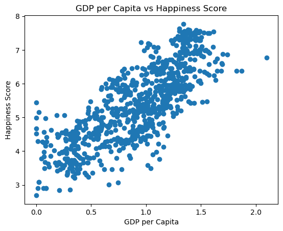

```python
plt.scatter(happiness_df['GDP_per_Capita'], happiness_df['Happiness_Score'])
plt.xlabel('GDP per Capita')
plt.ylabel('Happiness Score')
plt.title('GDP per Capita vs Happiness Score')
plt.show()
```

We will use Pearson's correlation coefficient for this hypothesis test because we are dealing with continuous variables, and our previous scatter plot suggests that there is a linear relationship.

For a deeper understanding of Pearson's correlation coefficient: https://www.geeksforgeeks.org/pearson-correlation-coefficient/

```python
result = pearsonr(happiness_df['GDP_per_Capita'], happiness_df['Happiness_Score'])
print(f'P-value: {result.pvalue}')
```

```
P-value: 2.213787835429655e-167
```

Since the p-value is less than our significance level of 0.05, we reject the null hypothesis, concluding that the GDP per Capita does have an effect on happiness score.

### Second Hypothesis (Correlation between Social Support and Happiness Score (2019))

Assume $\alpha = 0.05$.  
HO: There is no linear relationship between Social Support and Happiness Score (r = 0).  
HA: There is a linear relationship between Social Support and Happiness Score (r ≠ 0).

```python
data_2019 = happiness_df[happiness_df['Year'] == 2019]
x = data_2019['Social_Support']
y = data_2019['Happiness_Score']

r_value, p_value = pearsonr(x, y)

print("Pearson correlation coefficient (r):", r_value)
print("P-value:", p_value)
```

```
Pearson correlation coefficient (r): 0.7770577880638643
P-value: 8.975119655183162e-33
```

Since the p-value is less than our significance level of 0.05, we reject the null hypothesis, concluding that the Social Support does have an effect on happiness score.

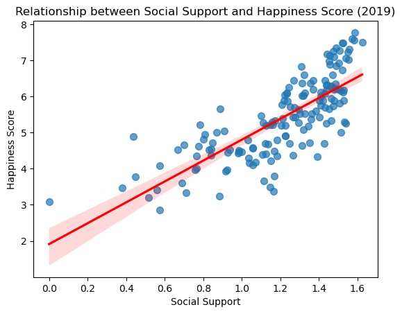

```python
plt.figure()
sns.regplot(x='Social_Support', y='Happiness_Score', data=data_2019,
            scatter_kws={'s':50, 'alpha':0.7}, line_kws={'color':'red'})
plt.xlabel('Social Support')
plt.ylabel('Happiness Score')
plt.title('Relationship between Social Support and Happiness Score (2019)')
plt.show()
```

### Third Hypothesis (Comparing Happiness Score between 2015 and 2019 (two sample t-test))

Assume $\alpha = 0.05$.  
HO: The mean Happiness Score in 2019 is equal to that in 2015.  
HA: The mean Happiness Score in 2019 is not equal to that in 2015.

```python
data_2015 = happiness_df[happiness_df['Year'] == 2015]['Happiness_Score'].dropna()
data_2019 = happiness_df[happiness_df['Year'] == 2019]['Happiness_Score'].dropna()

t_stat, p_val = ttest_ind(data_2019, data_2015, equal_var=False)

print("Hypothesis Test: Comparing Happiness Score (2019 vs 2015)")
print("Null Hypothesis (H0): μ_2019 = μ_2015")
print("Alternative Hypothesis (H1): μ_2019 ≠ μ_2015")
print("T-statistic:", t_stat)
print("P-value:", p_val)

if p_val < 0.05:
    print("Result: Reject H0. There is a statistically significant difference in Happiness Scores between 2019 and 2015.")
else:
    print("Result: Fail to reject H0. There is no statistically significant difference in Happiness Scores between 2019 and 2015.")
```

```
Hypothesis Test: Comparing Happiness Score (2019 vs 2015)
Null Hypothesis (H0): μ_2019 = μ_2015
Alternative Hypothesis (H1): μ_2019 ≠ μ_2015
T-statistic: 0.24609696456854885
P-value: 0.8057690323213097
Result: Fail to reject H0. There is no statistically significant difference in Happiness Scores between 2019 and 2015.
```

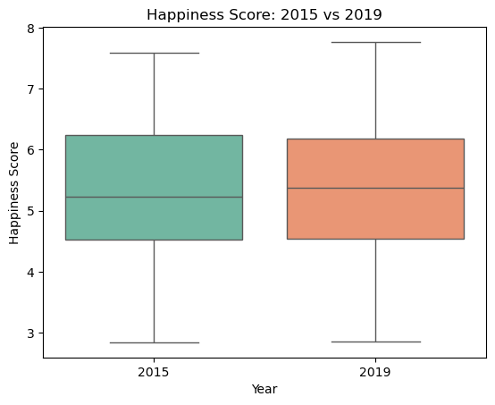

```python
plt.figure()
sns.boxplot(x='Year', y='Happiness_Score', data=happiness_df[happiness_df['Year'].isin([2015, 2019])],
            hue='Year', palette='Set2')
plt.xlabel('Year')
plt.ylabel('Happiness Score')
plt.title('Happiness Score: 2015 vs 2019')
plt.legend([], [], frameon=False)
plt.show()
```

### Fourth Hypothesis (Effect of Region on Happiness Score)

Assume $\alpha = 0.05$.  
HO: Region does not have an effect on the Happiness Score of a country.  
HA: Region does have an effect on the Happiness Score of a country.

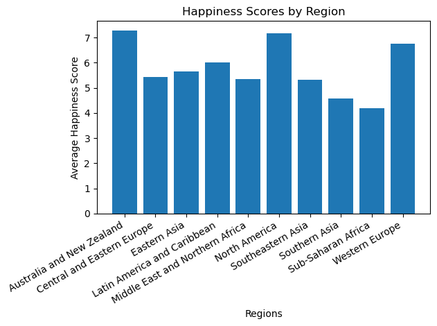

```python
# First we split the countries by region
regions = []
mean_happiness_scores = []
raw_data = []
groups = happiness_df.groupby('Region')
# Then we calculate the mean happiness score per region
for (name, group_df) in groups:
    regions.append(name)
    raw_data.append(group_df['Happiness_Score'].values)
    mean_happiness_scores.append(group_df['Happiness_Score'].mean())
# Finally, we plot the results in a bar chart
plt.bar(regions, mean_happiness_scores)
plt.title('Happiness Scores by Region')
plt.xlabel('Regions')
plt.ylabel('Average Happiness Score')
plt.xticks(rotation=30, ha='right')  # Rotate and align right
plt.tight_layout()  # Prevent labels from getting cut off
plt.show()
```

Visually, it looks like the regions make a difference. Let us do an ANOVA test to make sure.

More on ANOVA: https://www.datacamp.com/tutorial/anova-test

```python
statistic, p_val = f_oneway(*raw_data)
print("P value: " + str(p_val))
```

```
P value: 9.82996034149784e-155
```

Since our p-value is less than 0.05, our One-Way ANOVA test confirms that region affects happiness score. Therefore, we must reject our null hypothesis.

## Primary Analysis

### Feature Engineering

Prepare the data for machine learning techniques such as [linear regression](https://www.geeksforgeeks.org/ml-linear-regression/) and [random forest](https://williamkoehrsen.medium.com/random-forest-simple-explanation-377895a60d2d).

Also, splitting the data into training and testing data sets to test the accuracy of our model.

```python
# Feature selection, one-hot encoding for the regions
df = pd.get_dummies(happiness_df.drop(columns=['Country', 'Year']), columns=['Region'], drop_first=True)

# Define feature and target
X = df.drop(columns=['Happiness_Score'])
y = df['Happiness_Score']

print("Feature columns:")
print(list(X.columns), "\n")

X_train, X_test, y_train, y_test = train_test_split(X, y, test_size=0.2)

# Feature transformation - Scaling
scaler = StandardScaler()
X_train_scaled = scaler.fit_transform(X_train)
X_test_scaled = scaler.transform(X_test)

X_train_scaled_df = pd.DataFrame(X_train_scaled, columns=X.columns)
print("First 5 rows of scaled training features:")
print(X_train_scaled_df.head(), "\n")
```

[output not shown]

### Training and Testing Linear Regression Model

Training the regression model and then testing on the unseen data. Using R-Squared, mean absolute error, and mean squared error.

```python
linear_regression = LinearRegression()
linear_regression.fit(X_train_scaled, y_train)
linear_y_pred = linear_regression.predict(X_test_scaled)
lr_r2 = round(r2_score(y_test, linear_y_pred), 4)
lr_mae = round(mean_absolute_error(y_test, linear_y_pred), 4)
lr_mse = round(mean_squared_error(y_test, linear_y_pred), 4)

print("R-Squared Score:", lr_r2)
print("Mean Absolute Error:", lr_mae)
print("Mean Squared Error:", lr_mse)
```

```
R-Squared Score: 0.782
Mean Absolute Error: 0.4046
Mean Squared Error: 0.2694
```

### Training and Testing Random Forest Model

```python
random_forest = RandomForestRegressor()
random_forest.fit(X_train, y_train)
random_forest_y_pred = random_forest.predict(X_test)
rf_r2 = round(r2_score(y_test, random_forest_y_pred), 4)
rf_mae = round(mean_absolute_error(y_test, random_forest_y_pred), 4)
rf_mse = round(mean_squared_error(y_test, random_forest_y_pred), 4)

print("Random Forest Regressor Evaluation:")
print("R-Squared Score:", rf_r2)
print("Mean Absolute Error:", rf_mae)
print("Mean Squared Error:", rf_mse)
```

```
Random Forest Regressor Evaluation:
R-Squared Score: 0.8608
Mean Absolute Error: 0.3175
Mean Squared Error: 0.1721
```

#### Feature Importances

```python
# Get feature importances
importances = random_forest.feature_importances_
feature_names = X.columns
feature_importance_df = pd.DataFrame({
    'Feature': feature_names,
    'Importance': importances
}).sort_values(by='Importance', ascending=False)

print("Top Features Driving Happiness Predictions:")
print(feature_importance_df)
```

```
Top Features Driving Happiness Predictions:
                                   Feature  Importance
0                           GDP_per_Capita    0.513147
2                  Healthy_Life_Expectancy    0.200571
3                                  Freedom    0.093569
8       Region_Latin America and Caribbean    0.056391
1                           Social_Support    0.041059
4                Perceptions_of_Corruption    0.035669
5                               Generosity    0.030087
13               Region_Sub-Saharan Africa    0.012217
7                      Region_Eastern Asia    0.005437
6        Region_Central and Eastern Europe    0.005070
9   Region_Middle East and Northern Africa    0.002016
12                    Region_Southern Asia    0.001975
14                   Region_Western Europe    0.001672
11                Region_Southeastern Asia    0.000794
10                    Region_North America    0.000326
```

## Visualization

### Model Comparison

Let us compare our Linear Regression Model and Random Forest Models:

[figure not shown]

```python
x = np.array([0,1])
R2 = [lr_r2, rf_r2]
MAE = [lr_mae, rf_mae]
MSE = [lr_mae, rf_mse]
width = 0.20

plt.title("Comparison of Models")
plt.bar(x-0.2, R2, width)
plt.bar(x, MAE, width)
plt.bar(x+0.2, MSE, width)
plt.xticks(x, ['Linear Regression Model', 'Random Forest Model'])
plt.legend(["R-Squared Score", "Mean Absolute Error", "Mean Squared Error"], loc='upper center', bbox_to_anchor=(0.5, -0.1), ncol=3)
plt.show()
```

The Random Forest Model is the superior model across all three metrics with less error overall and a better fit to the testing data.

### Feature Importances

It is also interesting to examine the feature importances:

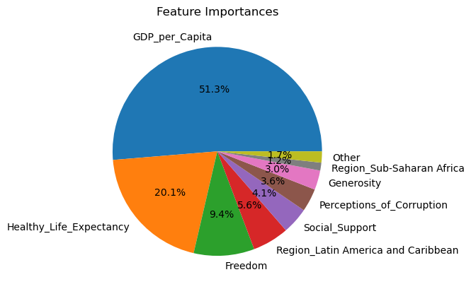

```python
labels = feature_importance_df.loc[feature_importance_df['Importance'] > 0.01, 'Feature']
sizes = feature_importance_df.loc[feature_importance_df['Importance'] > 0.01, 'Importance']
other = 1- sum(sizes)
labels = pd.concat([labels, pd.Series(['Other'])], ignore_index=True)
sizes = pd.concat([sizes, pd.Series([other])], ignore_index=True)

fig, ax = plt.subplots()
ax.pie(sizes, labels=labels,autopct='%1.1f%%');
ax.set_title('Feature Importances')
plt.show()
```

## Insights and Conclusions

1. Wealth is a Large Factor for Happiness

2. Health and Autonomy

Other than money, two other factors are also noticeably dominant. Healthy life expectancy is the second most important predictor (approximately 20% importance), indicating that healthier, longer lives reduce pressure and allow people to enjoy the fruits of their work. Freedom to choose in life is third (approximately 9% importance), showing the value of civil liberties. These factors go hand in hand, healthy individuals can better use their freedoms, and freedom to make good choices encourages healthier living.

3. Social Support

Social support is also important. Although it accounts for only about 4% of the Random Forest’s power, its Pearson correlation with Happiness Score in 2019 is $r \approx 0.78$ with ($p \approx 9.0 * 10^{-33}$), showing a strong association. This implies that community programs, mental‑health services, and civic‑engagement policies can add substantial benefits in well‑being.

4. Regional Differences

The one‑way ANOVA shows a highly significant difference in mean Happiness Scores across world regions ($p \approx 9.8 * 10^{-155}$). Western Europe and North America average around 7.0 on the 0–10 scale, while Sub‑Saharan Africa and South Asia average around 4.5. However, when region is included alongside GDP, health, and social support in the Random Forest, all regional variables each contribute less than 1.5% importance (bar Latin America and Caribbean). This shows that “region” is not a root cause but a byproduct for clusters of economic and social conditions. Regional development efforts should target more income, health systems, and social infrastructure rather than geography.

5. Happiness over Time

The 2015 vs. 2019 two‑sample t‑test comparison yields $t \approx 0.25$, $p \approx 0.81$, indicating no statistically significant change in the global average Happiness Score (both years are approximately 5.3). This highlights the importance of examining country‑level trends, since a stable world average could hide major country specific shifts.